# Practico 12

# visualizando datos

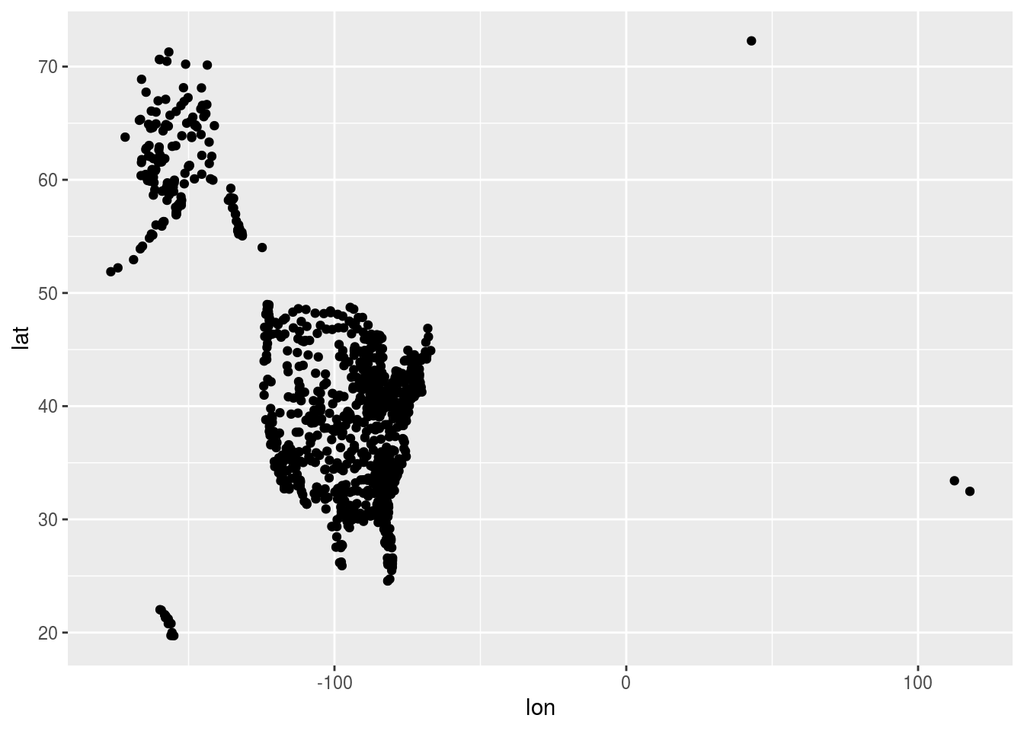

```r
# realizamos un plot sencillo
vuelos_final %>%
  ggplot(data = .,
         mapping = aes(x = lon, y = lat)) +
  geom_point()
```

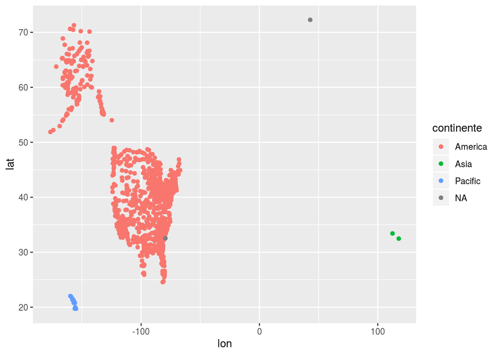

```r
# podemos colorear segun los continentes o las ciudades
vuelos_final %>%
  ggplot(data = .,
         mapping = aes(x = lon, y = lat, color = continente)) +
  geom_point()
```

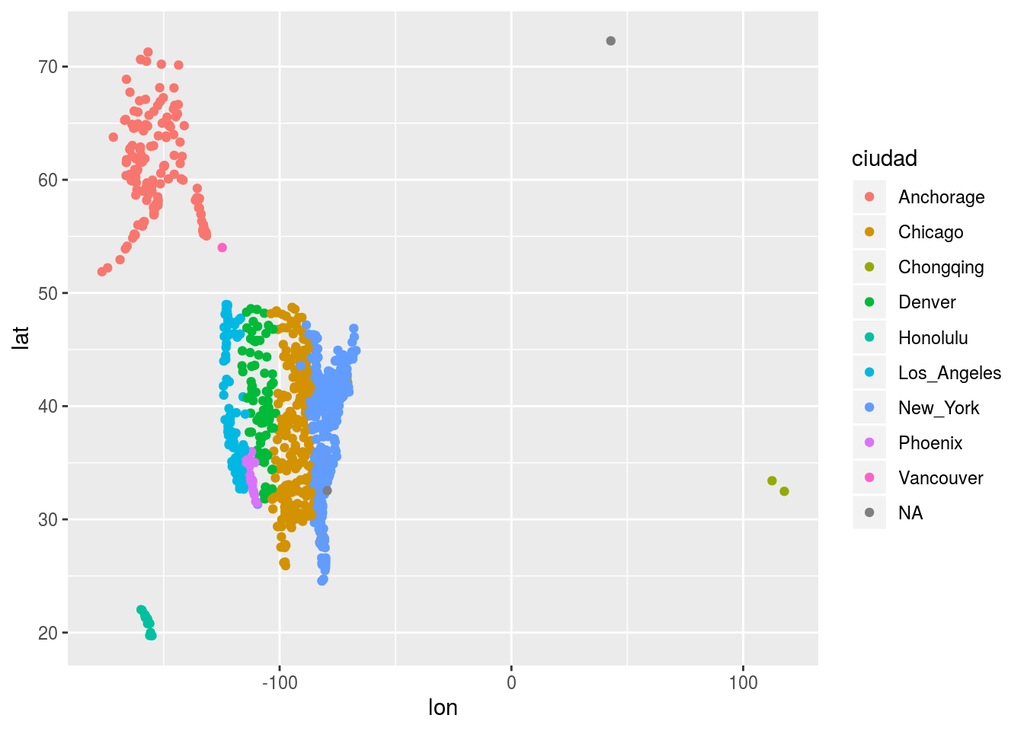

```r
vuelos_final %>%
  ggplot(data = .,
         mapping = aes(x = lon, y = lat, color = ciudad)) +
  geom_point()
```

### Ejercicio 4.1

*a)* Grafique la expectativa de vida en función del GDP per capita (). *b)* Modifique el código anterior para colorear en función del continente. *c)* Filtre para obtener, además, solo datos para África y Europa. *d)* Seleccione datos para África, y coloree en función del país.

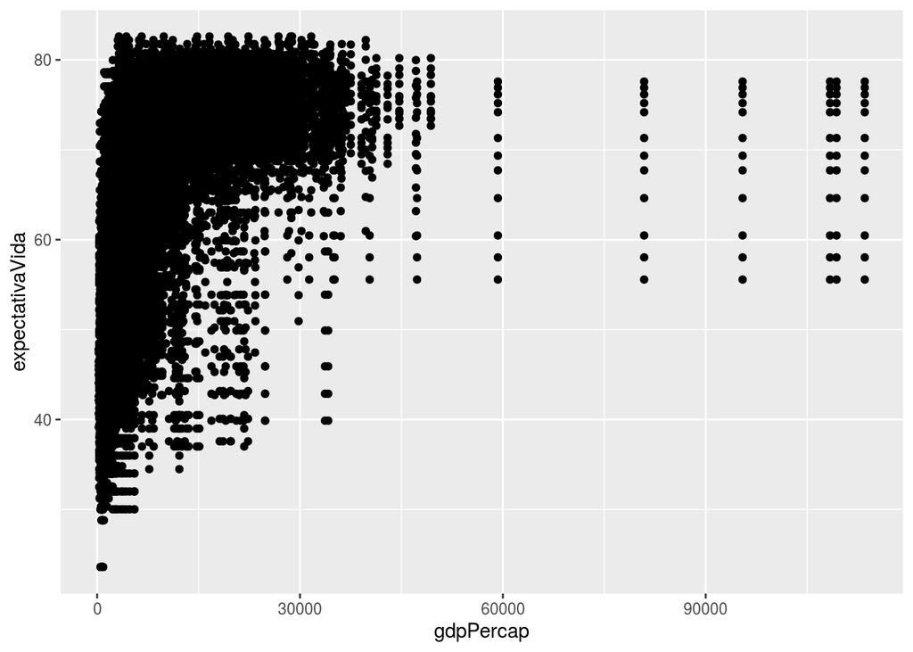

```r
# a)
gapminder_final %>%
  ggplot(data = .,
         mapping = aes(x = gdpPercap, y = expectativaVida)) +
  geom_point()
```

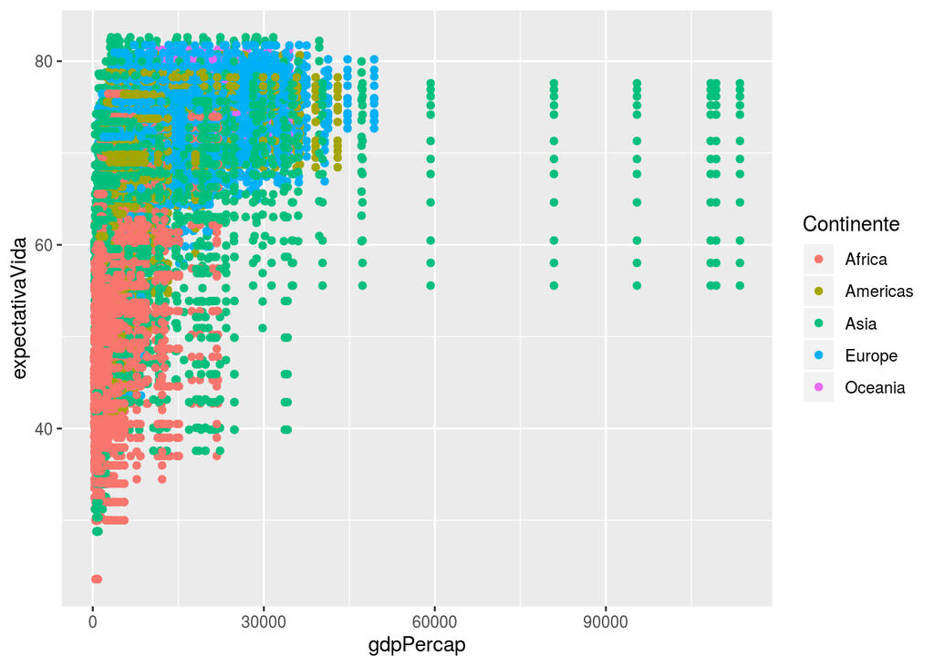

```r
# b)
gapminder_final %>%
  ggplot(data = .,
         mapping = aes(x = gdpPercap, y = expectativaVida, color = Continente)) +
  geom_point()
```

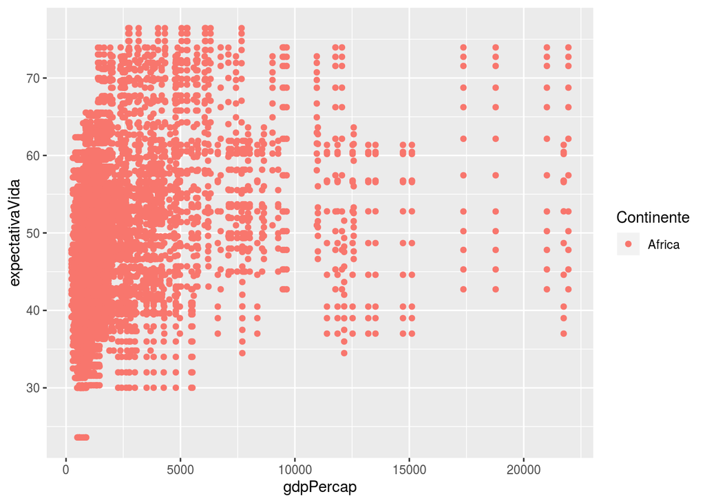

```r
# c)
gapminder_final %>%
  filter(., Continente == 'Africa' | Continente == 'Europa') %>%
  ggplot(data = .,
         mapping = aes(x = gdpPercap, y = expectativaVida, color = Continente)) +
  geom_point()
```

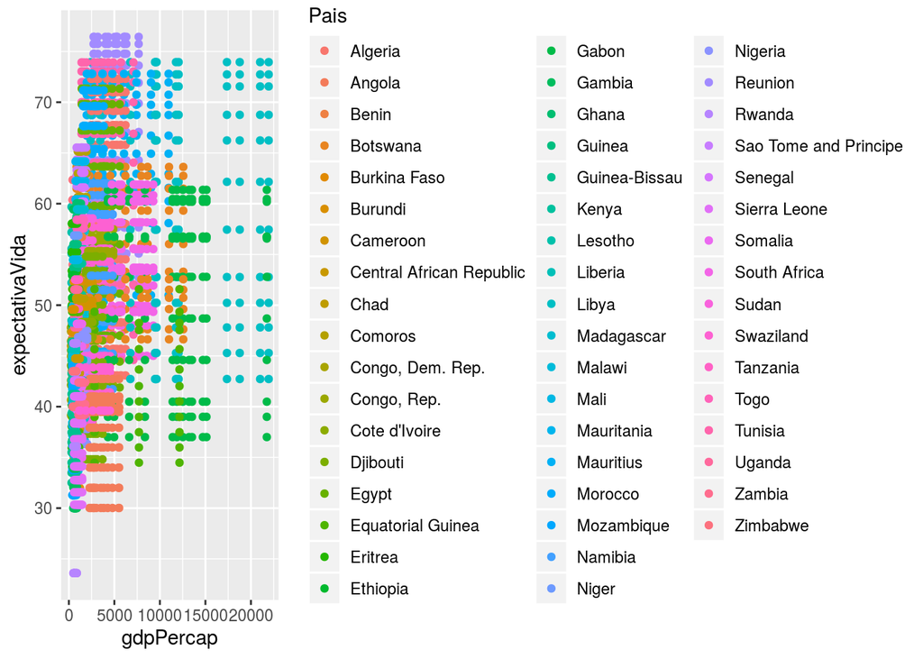

```r
# d)
gapminder_final %>%
  filter(., Continente == 'Africa') %>%
  ggplot(data = .,
         mapping = aes(x = gdpPercap, y = expectativaVida, color = Pais)) +
  geom_point()
```

# modificamos un poco mas (dplyr)

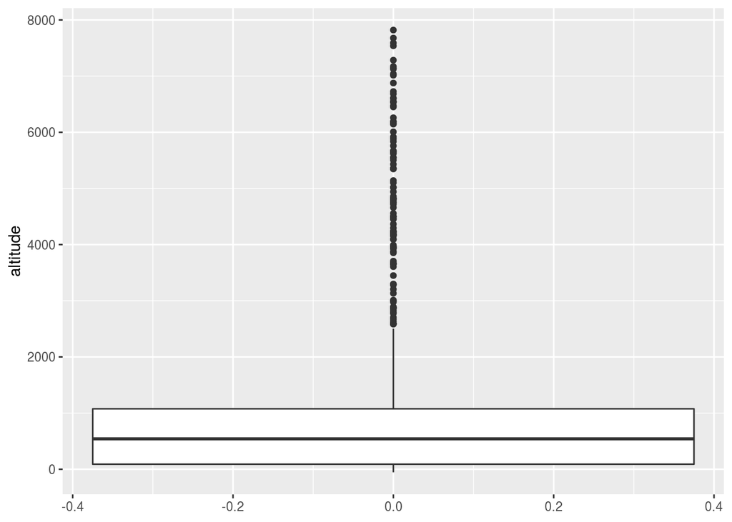

```r
# ahora clasificaremos los vuelos segun tres tipos de altitudes: altas, medianas y bajas
# primero vamos a ver como se distribuyen estas altitudes
vuelos_final %>%
  ggplot(data = .,
         mapping = aes(y = altitude)) +
  geom_boxplot()
```

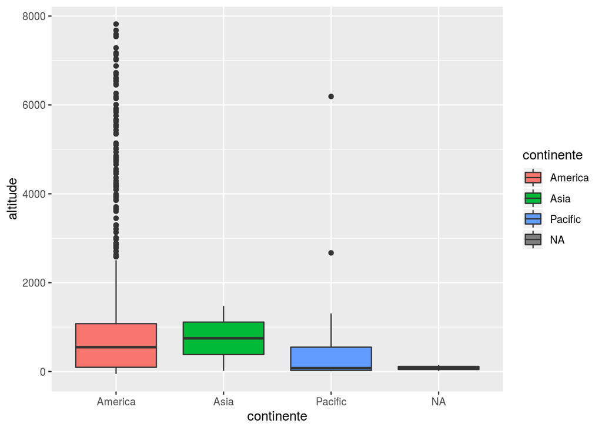

```r
vuelos_final %>%
  ggplot(data = .,
         mapping = aes(y = altitude, x = continente, fill = continente)) +
  geom_boxplot()
```

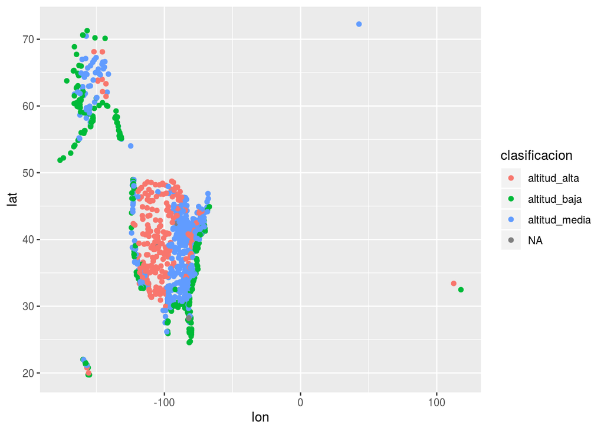

```r
# pasamos ahora a hacer la clasificacion
## lo haremos en base a lo reportado por la funcion quantile()
quantiles_alt = quantile(vuelos_final$altitude)

vuelos_final %<>%
  dplyr::mutate(., clasificacion = case_when(altitude < quantiles_alt[2] ~ 'altitud_baja',
                                             altitude > quantiles_alt[2] &
                                             quantiles_alt[4] > altitude ~ 'altitud_media',
                                             altitude > quantiles_alt[4] &
                                             quantiles_alt[5] > altitude ~ 'altitud_alta')
                )

# ahora podemos visualizar esto de diferentes maneras
vuelos_final %>%
  ggplot(data = .,
         mapping = aes(x = lon, y = lat, color = clasificacion)) +
  geom_point()
```

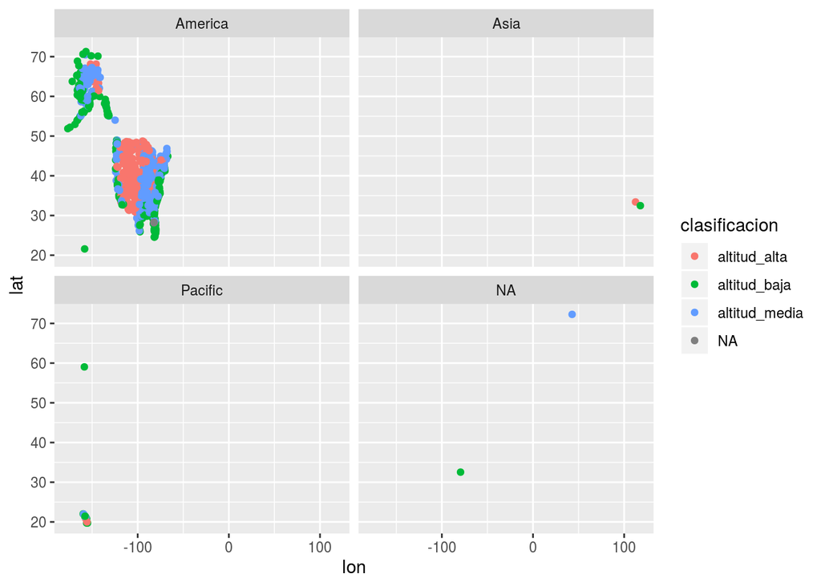

```r
vuelos_final %>%
  ggplot(data = .,
         mapping = aes(x = lon, y = lat, color = clasificacion)) +
  geom_point() +
  facet_wrap(~continente)
```

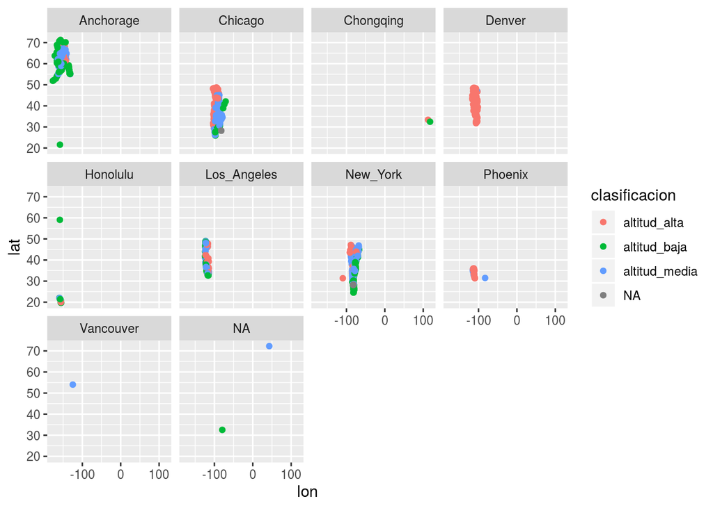

```r
vuelos_final %>%
  ggplot(data = .,
         mapping = aes(x = lon, y = lat, color = clasificacion)) +
  geom_point() +
  facet_wrap(~ciudad)
```

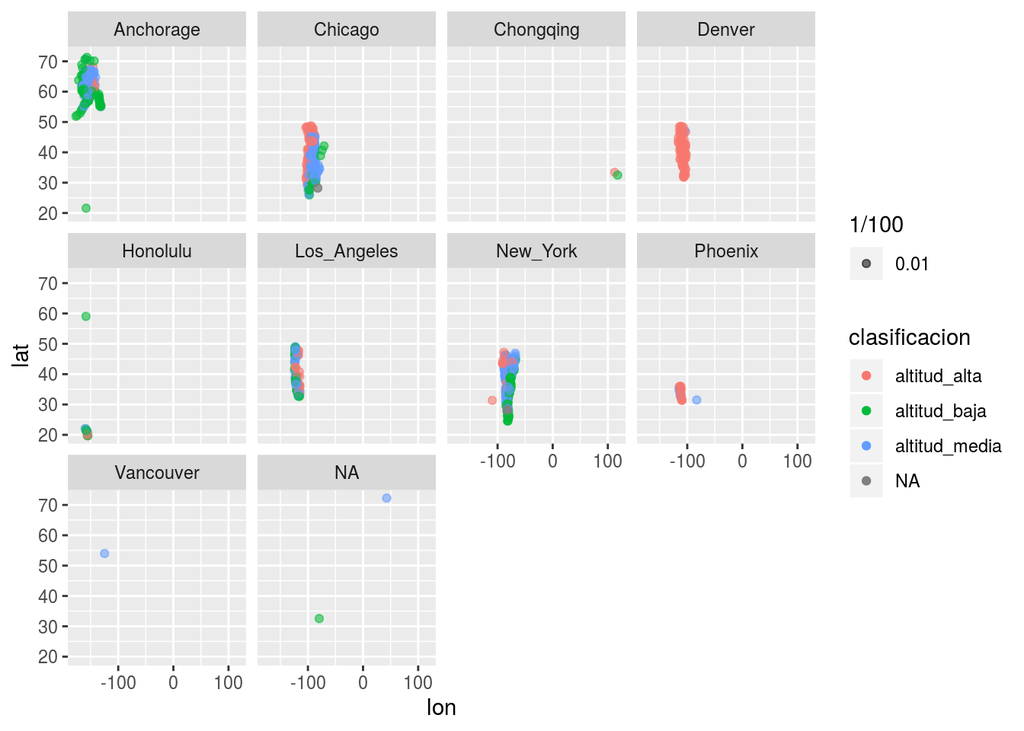

```r
# para ver mejor incluso podemos dar poca intensidad al coloreado
vuelos_final %>%
  ggplot(data = .,
         mapping = aes(x = lon, y = lat, color = clasificacion, alpha = 1/100)) +
  geom_point() +
  facet_wrap(~ciudad)
```

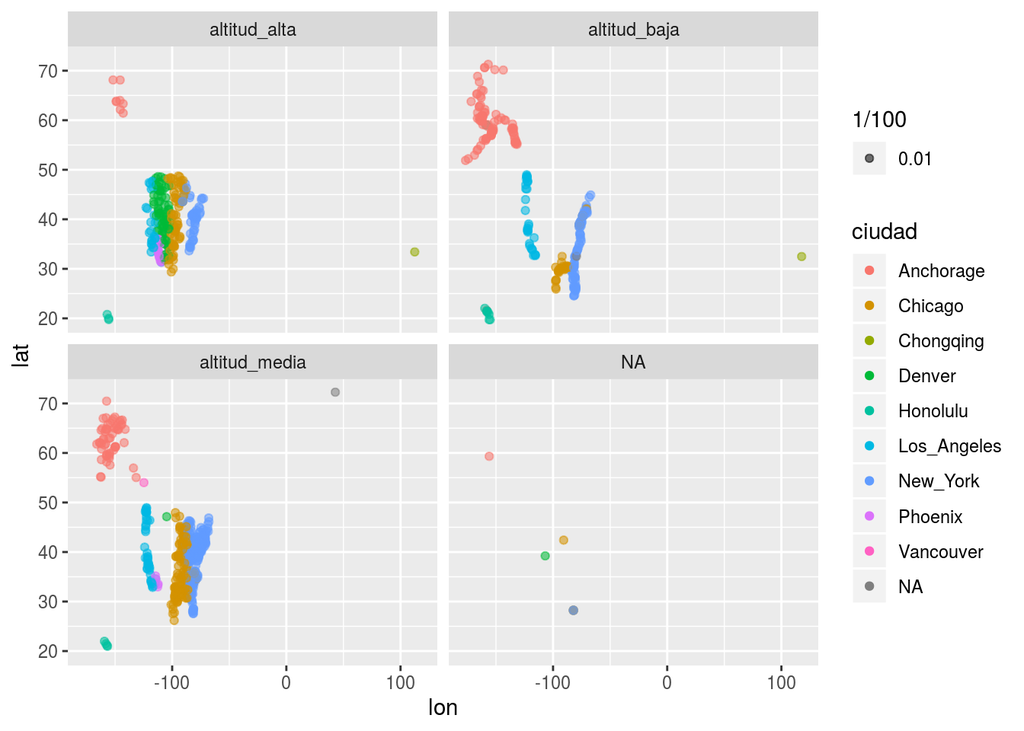

```r
vuelos_final %>%
  ggplot(data = .,
         mapping = aes(x = lon, y = lat, color = ciudad, alpha = 1/100)) +
  geom_point() +
  facet_wrap(~clasificacion)
```

```r
library(tibble)
as_tibble(iris)
```

# Cargando datos: readr

```r
library(readr)

aeropuertos = readr::read_tsv('airports.tsv')

aeropuertos
```

## Ejercico 1

```r
# cargamos librerias
library(readr)
library(magrittr)
library(dplyr)

# cargamos los datasets
dataset_pollo = readr::read_tsv('KallistoNormalizedTPM_Chicken.txt')
dataset_raton = readr::read_tsv('KallistoNormalizedTPM_Mouse.txt')
dataset_rata = readr::read_tsv('KallistoNormalizedTPM_Rat.txt')

# vemos que columnas son compartidas entre los datasets, a fin de crear un unico set de datos con el que trabajar
columnas_compartidas = dplyr::intersect(x = colnames(dataset_pollo), y = colnames(dataset_raton)) %>%
  dplyr::intersect(x = ., y = colnames(dataset_rata))

# unimos los datasets
### esto hay que hacerlo con un loop capaz
dataset_pollo %<>% dplyr::select(columnas_compartidas)
dataset_raton %<>% dplyr::select(columnas_compartidas)
dataset_rata %<>% dplyr::select(columnas_compartidas)

# agregamos un tag para identificar de donde viene cada dataset
dataset_pollo %<>% dplyr::mutate(., set = 'pollo')
dataset_raton %<>% dplyr::mutate(., set = 'raton')
dataset_rata %<>% dplyr::mutate(., set = 'rata')

dataset_final = dplyr::bind_rows(dataset_pollo, dataset_raton, dataset_rata)
```

# Filtrado de datos

```r
library(dplyr)
library(stringr)

aeropuertos %>%
  filter(lat > -100)

aeropuertos %>%
  filter(lat > -100 & lon > 100)

aeropuertos %>%
  filter(lat > -100 & lon > 100 & stringr::str_detect(string = tzone, 'Asia'))
```

# Modificación y agregado de datos

```r
aeropuertos %>%
  mutate(., continent = stringr::str_split(tzone, '/') %>% purrr::map_chr(1))
```

# Visualización de datos: ggplot2

```r
library(ggplot2)

aeropuertos %>%
  mutate(., continent = stringr::str_split(tzone, '/') %>% purrr::map_chr(1)) %>%
  ggplot(data = .,
         mapping = aes(x = lon, y = lat)) +
  geom_point()
```

[output not shown]

```r
library(ggplot2)
library(reshape2)
library(purrr)

# visualizando todos los datos juntos
dataset_final %>%
  group_split(set) %>%
  purrr::map_dfr(., ~{
    .[1:3000,]
    }
  ) %>%
  melt() %>%
  as_tibble() %>%
  dplyr::rename(tejido = 'variable', TPM = 'value') %>%
  ggplot(data = .,
         mapping = aes(x = set, y = TPM, fill = tejido, color = tejido)
         ) +
  geom_point()
  #facet_wrap(~tejido)

# por set
  dataset_final %>%
  group_split(set) %>%
  purrr::map_dfr(., ~{
    .[1:3000,]
    }
  ) %>%
  melt() %>%
  as_tibble() %>%
  dplyr::rename(tejido = 'variable', TPM = 'value') %>%
  ggplot(data = .,
         mapping = aes(x = set, y = TPM, fill = tejido, color = tejido)
         ) +
  geom_point() +
  facet_wrap(~tejido)

  # realizando algunas modificaciones podemos dividir entre los tejidos en si
  library(stringr)

  dataset_final %>%
  group_split(set) %>%
  purrr::map_dfr(., ~{
    .[1:5000,]
    }
  ) %>%
  melt() %>%
  as_tibble() %>%
  dplyr::rename(tejido = 'variable', TPM = 'value') %>%
  mutate(set_tejido = str_split(tejido, '_') %>% purrr::map_chr(1)) %>%
  ggplot(data = .,
         mapping = aes(x = tejido, y = TPM, fill = set, color = set, group = set_tejido, alpha = 0.3)
         ) +
  geom_point() +
  theme(axis.text.x = element_text(angle = 90, hjust = 1)) +
  facet_wrap(~set_tejido, scales = 'free_x')

  # nos focalizamos en algunos genes
  dataset_final %>%
  group_split(set) %>%
  purrr::map_dfr(., ~{
    .[1:5000,]
    }
  ) %>% filter(Liver_LateEmbryo2 > 40000) %>% .$GeneID -> genes_interes

  dataset_final %>%
  group_split(set) %>%
  purrr::map_dfr(., ~{
    .[1:5000,]
    }
  ) %>%
  #dplyr::select(GeneID, set, Liver_EarlyEmbryo1, Liver_EarlyEmbryo2, Liver_LateEmbryo1, Liver_LateEmbryo2) %>%
  melt() %>%
  as_tibble() %>%
  dplyr::rename(tejido = 'variable', TPM = 'value') %>%
  #filter(GeneID %in% genes_interes) %>%
  filter(TPM > 20000) %>%
  mutate(set_tejido = str_split(tejido, '_') %>% purrr::map_chr(1)) %>%
  ggplot(data = .,
         mapping = aes(x = tejido, y = TPM, fill = GeneID, color = GeneID, group = GeneID)
         ) +
  geom_line() +
  geom_point() +
  theme(axis.text.x = element_text(angle = 90, hjust = 1)) +
  facet_wrap(~set_tejido+set, scale = 'free_x')
```

[output not shown]

De una busqueda en Ensembl se ve que el gen **ENSRNOG00000002889** corresponde al gen *Afp*, un gen descrito como *‘Predicted to have fatty acid binding activity and zinc ion binding activity. Involved in animal organ development and response to organic substance. (…)’*.

**ENSRNOG00000002911**, a su vez, corresponde al gen *Alb*, la albumina.

- Incluir el tema de hacer facets y eso

# Algunos otros ejemplos

## Visualización de filogenias: ggtree

## Visualización de datos genómicos: BioCircos

## Algo tipo lo de ver cosas genomicas